# Workflow

Karlo Guidoni Martins

01 November, 2016, 22:16

## Pacotes necessários

```r
source("functions/ipak.R")
ipak(packages <- c("readxl", "reshape2", "magrittr", "flora",
                   "data.table", "ape", "phytools", "brranching",
                   "picante", "xlsx"))
```

```
##     readxl   reshape2   magrittr      flora data.table        ape
##       TRUE       TRUE       TRUE       TRUE       TRUE       TRUE
##   phytools brranching    picante       xlsx
##       TRUE       TRUE       TRUE      FALSE
```

## Entrada dos dados

- Usando o pacote `readxl` para ler os dados direto de uma planilha do Excel (nota¹: um arquivo ‘.csv’ aceita controle de versão e, além disso, não é uma extensão proprietária);
- A planilha tem os registros brutos (eu entraria com os dados de campo dessa forma);
- A planilha do Excel pode ainda conter colunas com as datas e os comentários dos dias de coleta. A função `read_excel` completará as células vazias com `NA`.
- Reservei a coluna `morphospecies` para os apelidos que darei às espécies no início das coletas;

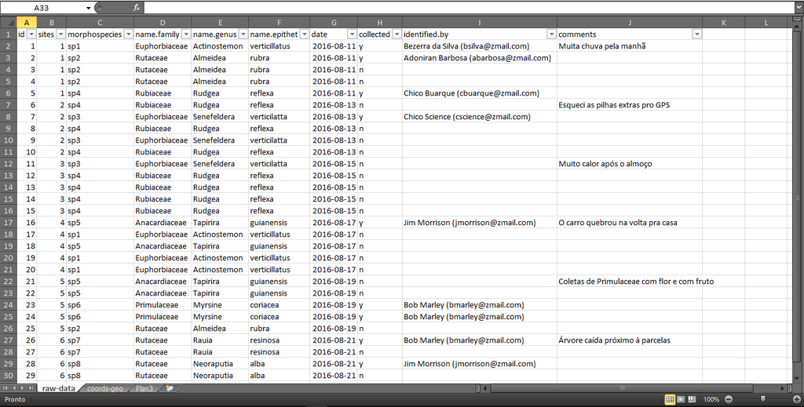

Exemplo de uma planilha com dados de campos

```r
raw.df <- read_excel("data/raw-data.xlsx", sheet = 1, col_names = TRUE)
str(raw.df) # estrutura da matriz e os tipos de variáveis contidas
```

```
## Classes 'tbl_df', 'tbl' and 'data.frame':    30 obs. of  10 variables:
##  $ id           : num  1 2 3 4 5 6 7 8 9 10 ...
##  $ sites        : num  1 1 1 1 1 2 2 2 2 2 ...
##  $ morphospecies: chr  "sp1" "sp2" "sp2" "sp2" ...
##  $ name.family  : chr  "Euphorbiaceae" "Rutaceae" "Rutaceae" "Rutaceae" ...
##  $ name.genus   : chr  "Actinostemon" "Almeidea" "Almeidea" "Almeidea" ...
##  $ name.epithet : chr  "verticillatus" "rubra" "rubra" "rubra" ...
##  $ date         : POSIXct, format: "2016-08-11" "2016-08-11" ...
##  $ collected    : chr  "y" "y" "n" "n" ...
##  $ identified.by: chr  "Bezerra da Silva (bsilva@zmail.com)" "Adoniran Barbosa (abarbosa@zmail.com)" NA NA ...
##  $ comments     : chr  "Muita chuva pela manhã" NA NA NA ...
```

## Limpando e transformando os dados

```r
new.df <-
  subset(
    raw.df,
    select = c(
      "sites",
      "morphospecies",
      "name.genus",
      "name.epithet"
      )
    )

# new.df$name.merged <-  # 'name.merged' será uma nova coluna
#   with(new.df,         # em 'new.df', contendo a
#        paste0(         # concatenação das strings em
#          name.genus,   # 'name.genus'
#          ".",          # mais um ponto (".") e
#          name.epithet  # name.epithet
#          )
#        )

new.df$name.coded <-          # 'name.coded' será uma nova coluna
  with(new.df,                # em 'new.df', contendo a
       paste0(                # concatenação das strings
         substr(              # que tiveram as letras extraídas
           name.genus, 1, 3   # 'name.genus' (da primeira à terceira letra)
           ),                 # mais
         ".",                 # um ponto (".") e
         substr(              #
           name.epithet, 1, 3 # 'name.epithet' (da primeira à terceira letra)
           )
         )
       )


str(new.df)
```

```
## Classes 'tbl_df', 'tbl' and 'data.frame':    30 obs. of  5 variables:
##  $ sites        : num  1 1 1 1 1 2 2 2 2 2 ...
##  $ morphospecies: chr  "sp1" "sp2" "sp2" "sp2" ...
##  $ name.genus   : chr  "Actinostemon" "Almeidea" "Almeidea" "Almeidea" ...
##  $ name.epithet : chr  "verticillatus" "rubra" "rubra" "rubra" ...
##  $ name.coded   : chr  "Act.ver" "Alm.rub" "Alm.rub" "Alm.rub" ...
```

## Tabela dinâmica com a função `ftable` do pacote `stats`

- Os *pipes* (`%>%`) mantêm uma cadeia de comandos.
- Pode-se usar tanto `morphospecies` quanto `name.coded` nos comandos a seguir:

### Gerando a matriz de comunidades com `morphospecies` nas colunas

```r
df1 <- ftable(morphospecies ~ sites, new.df) %>% # mantém df1 para a próxima função
  as.matrix(.) %>% # o ponto se refere à df1
  as.data.frame(.) # o ponto se refere à df1
df1
```

```
##   sp1 sp2 sp3 sp4 sp5 sp6 sp7 sp8
## 1   1   3   0   1   0   0   0   0
## 2   0   0   2   3   0   0   0   0
## 3   0   0   1   4   0   0   0   0
## 4   3   0   0   0   2   0   0   0
## 5   0   1   0   0   2   2   0   0
## 6   0   0   0   0   0   0   2   3
```

### Gerando a matriz de comunidades com `name.coded` nas colunas

- Repare que a ordem alfabética das colunas é mantida!

```r
df2 <- ftable(name.coded ~ sites, new.df) %>% # mantém df2 para a próxima função
  as.matrix(.) %>% # o ponto se refere à df2
  as.data.frame(.) # o ponto se refere à df2
df2      # chamando a matriz no console
```

```
##   Act.ver Alm.rub Myr.cor Neo.alb Rau.res Rud.ref Sen.ver Tap.gui
## 1       1       3       0       0       0       1       0       0
## 2       0       0       0       0       0       3       2       0
## 3       0       0       0       0       0       4       1       0
## 4       3       0       0       0       0       0       0       2
## 5       0       1       2       0       0       0       0       2
## 6       0       0       0       3       2       0       0       0
```

- Mas eu prefiro *rankear* a matriz das mais abundantes para as menos abundantes.

```r
df3 <- df2[order(colSums(df2), decreasing = TRUE)]
df3
```

```
##   Rud.ref Act.ver Alm.rub Tap.gui Neo.alb Sen.ver Myr.cor Rau.res
## 1       1       1       3       0       0       0       0       0
## 2       3       0       0       0       0       2       0       0
## 3       4       0       0       0       0       1       0       0
## 4       0       3       0       2       0       0       0       0
## 5       0       0       1       2       0       0       2       0
## 6       0       0       0       0       3       0       0       2
```

## Rápida exploração

- Criando mapas de distribuuição das abundâncias.

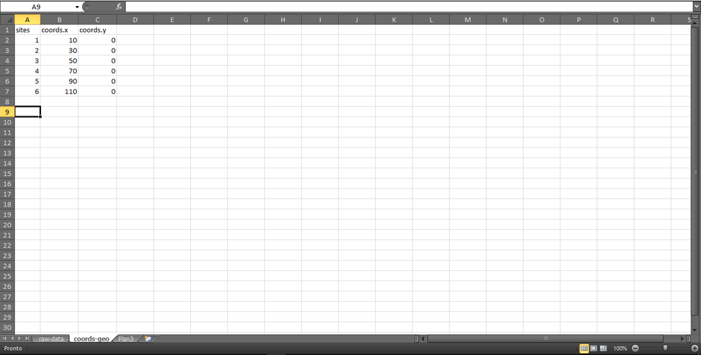

Exemplo de uma planilha com dados de campos

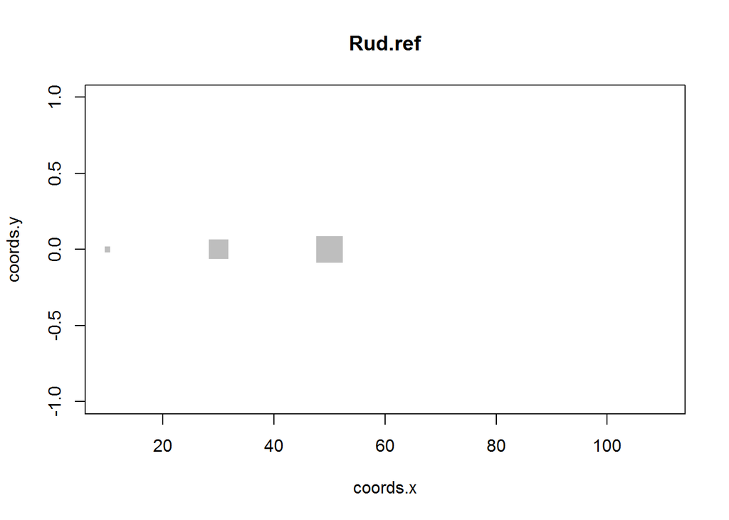

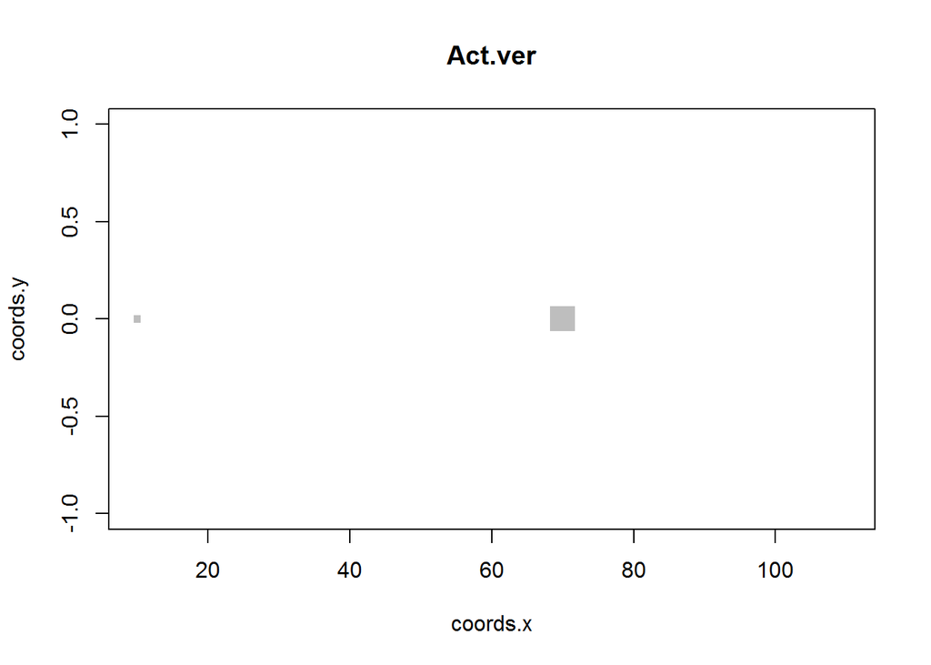

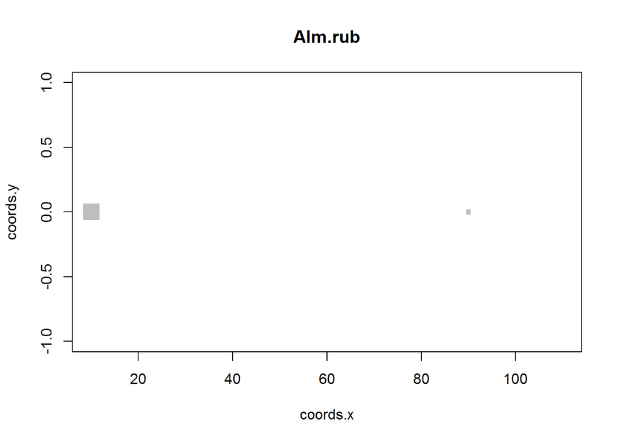

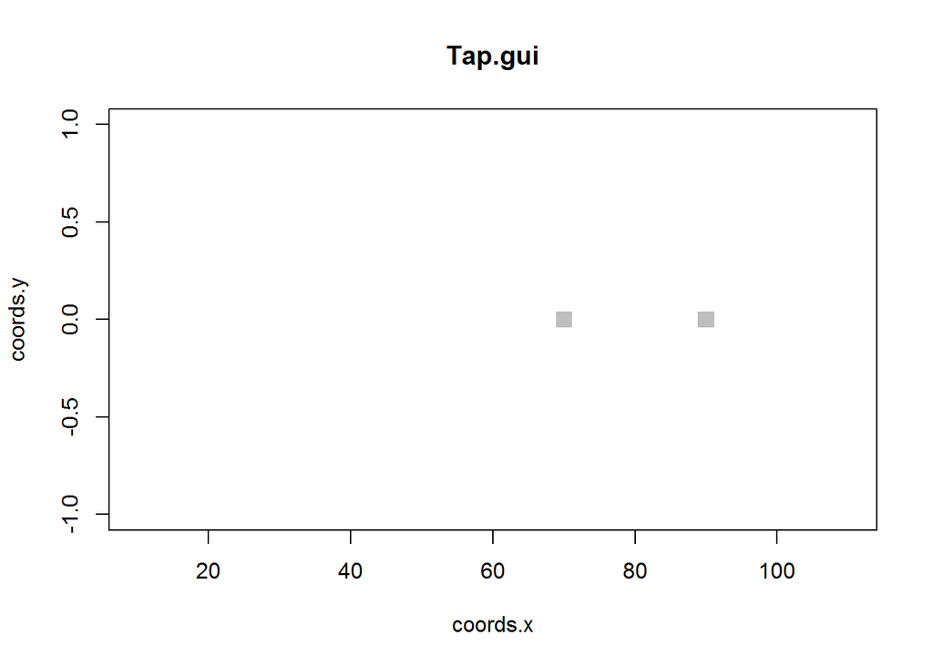

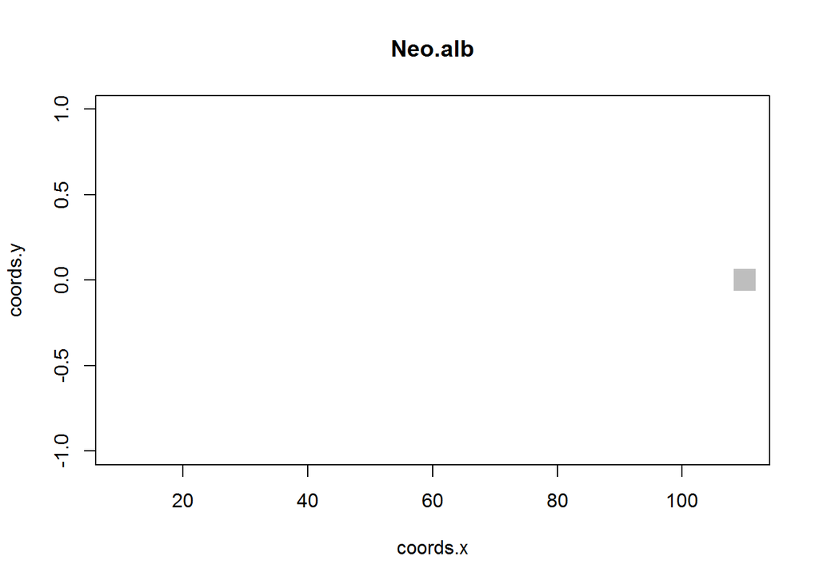

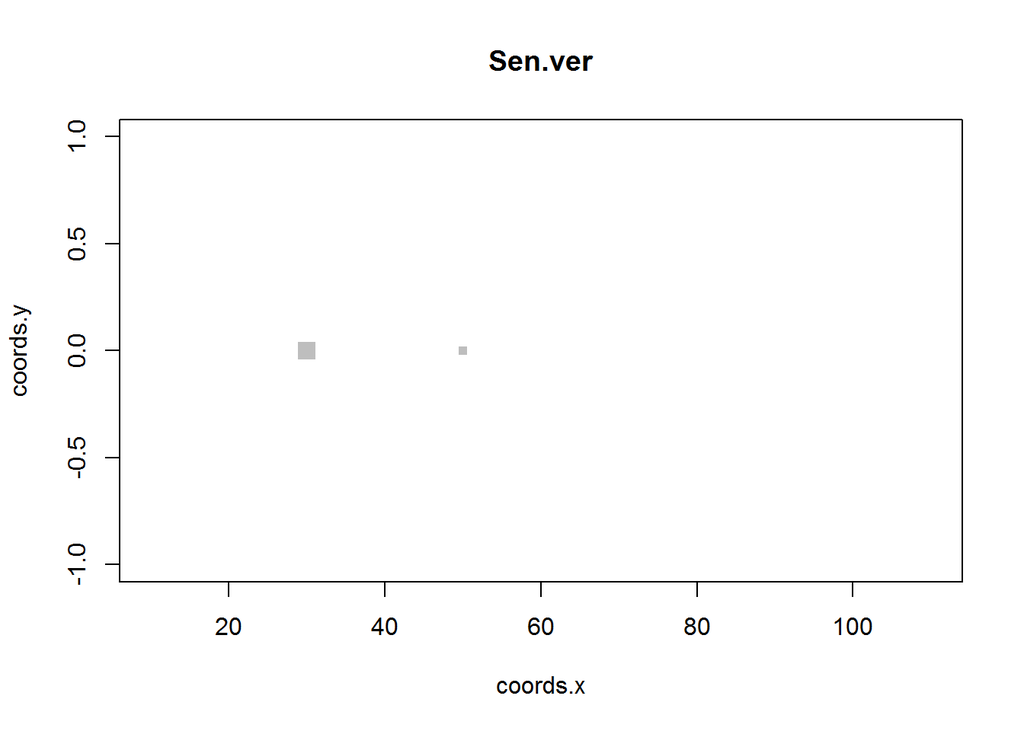

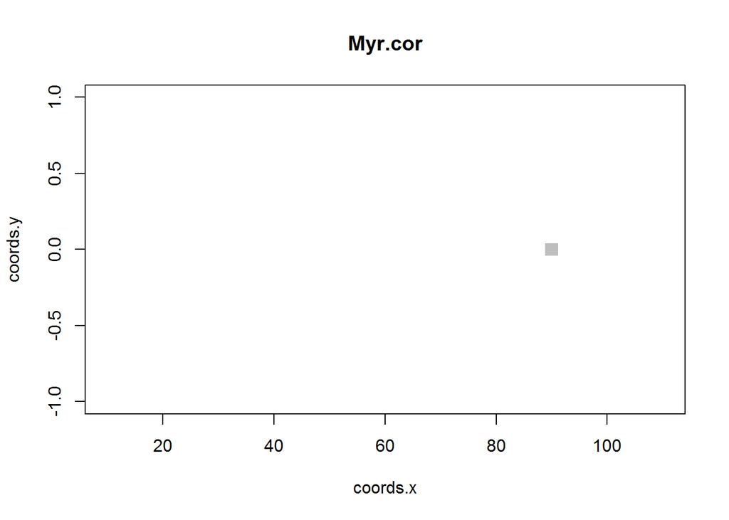

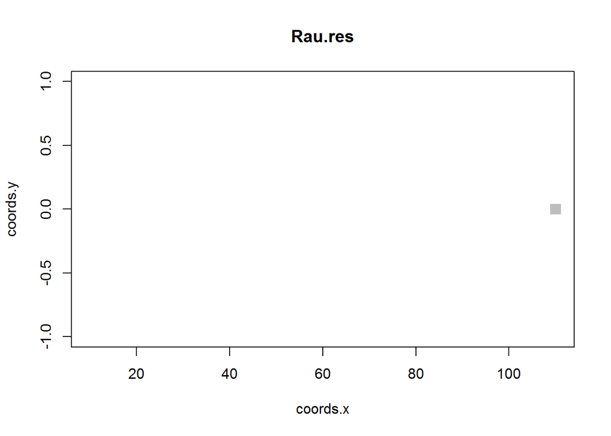

```r
xy <- read_excel("data/raw-data.xlsx", sheet = 2, col_names = TRUE) %>%
  .[,-1]

for (i in colnames(df3)) {
  plot(
  xy,
  cex = df3[, i],
  pch = 22,
  col = "white",
  bg = "gray"
  )
  title(names(df3[i]))
  }
```

## Obtendo informações da Lista da [Flora do Brasil](http://reflora.jbrj.gov.br/reflora/listaBrasil/ConsultaPublicaUC/ConsultaPublicaUC.do#CondicaoTaxonCP)

```r
raw.dt <- as.data.table(raw.df)

names.aggregated <-
  raw.dt[, list(.N), by = c("name.family",
                            "name.genus",
                            "name.epithet")]

names.aggregated
```

```
##      name.family   name.genus  name.epithet N
## 1: Euphorbiaceae Actinostemon verticillatus 4
## 2:      Rutaceae     Almeidea         rubra 4
## 3:     Rubiaceae       Rudgea       reflexa 8
## 4: Euphorbiaceae  Senefeldera  verticillata 3
## 5: Anacardiaceae     Tapirira    guianensis 4
## 6:   Primulaceae      Myrsine      coriacea 2
## 7:      Rutaceae        Rauia      resinosa 2
## 8:      Rutaceae   Neoraputia          alba 3
```

```r
query.flora <- paste0(names.aggregated$name.genus,
                      " ",
                      names.aggregated$name.epithet)

query.flora
```

```
## [1] "Actinostemon verticillatus" "Almeidea rubra"
## [3] "Rudgea reflexa"             "Senefeldera verticillata"
## [5] "Tapirira guianensis"        "Myrsine coriacea"
## [7] "Rauia resinosa"             "Neoraputia alba"
```

```r
names.flora.2020 <-
  get.taxa(
    query.flora,
    replace.synonyms = TRUE,
    suggest.names = TRUE,
    life.form = TRUE,
    habitat = TRUE,
    vernacular = TRUE,
    states = TRUE,
    establishment = TRUE,
    suggestion.distance = 1
  )
```

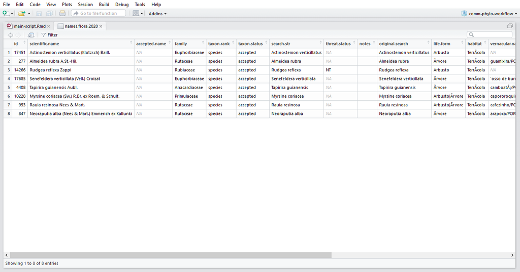

Exemplo das informações obtidas pelo pacote `flora`

## Organizando dados para análise filogenética

```r
phylomatic.names <-
  tolower(paste(names.aggregated$name.family,
                names.aggregated$name.genus,
                paste(names.aggregated$name.genus,
                      names.aggregated$name.epithet,
                      sep = "_"),
                sep = "/"))

phylomatic.names
```

```
## [1] "euphorbiaceae/actinostemon/actinostemon_verticillatus"
## [2] "rutaceae/almeidea/almeidea_rubra"
## [3] "rubiaceae/rudgea/rudgea_reflexa"
## [4] "euphorbiaceae/senefeldera/senefeldera_verticillata"
## [5] "anacardiaceae/tapirira/tapirira_guianensis"
## [6] "primulaceae/myrsine/myrsine_coriacea"
## [7] "rutaceae/rauia/rauia_resinosa"
## [8] "rutaceae/neoraputia/neoraputia_alba"
```

```r
get.tree.phylomatic <-
  phylomatic(
    phylomatic.names,
    taxnames = FALSE,
    informat = "newick",
    method = "phylomatic",
    storedtree = "R20120829",
    outformat = "newick",
    clean = FALSE, # influência no plot
    db = "apg",
    verbose = TRUE
  )
```

### Árvore filogenética não datada

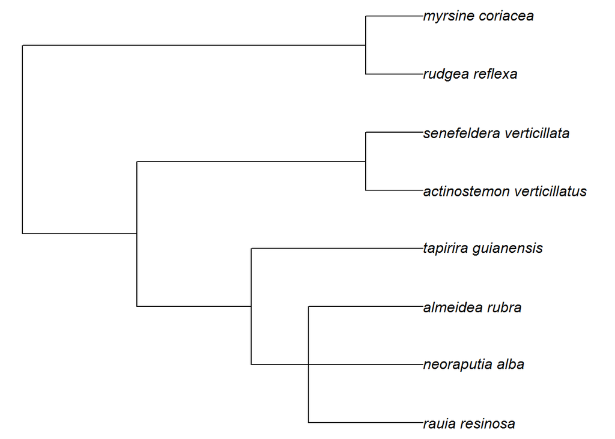

```r
# se o 'clean = TRUE', use a função plot direto.
# plot(get.tree.phylomatic)
plot(collapse.singles(get.tree.phylomatic), no.margin=TRUE)
```

```r
###############################################################################
################### PHYLOCOM WORKFLOW #########################################
###############################################################################

# Uma pequena adaptação baseada em:
# https://greggilbertlab.sites.ucsc.edu/wp-content/uploads/sites/276/2015/10/R_Class10b_PicatePhylomatic.pdf

# temp <- tempfile()
# download.file("http://phylodiversity.net/phylocom/phylocom-4.2.zip", temp, mode = "wb")
# unzip(temp)

# setwd("phylocom-4.2/w32")
# getwd()
#
# write.tree(get.tree.phylomatic, "tree-phylomatic")
#
# file.rename(from = "../example_data/bladj_example/wikstrom.ages",
#            to = "ages")
#
# dated.tree <- system("phylocom bladj -f tree-phylomatic > dated-tree",
#                      intern = TRUE)
#
# write(dated.tree, "dated-tree")
#
# dated.clean <- scan("dated-tree", what = "character", nmax = -1, sep = "]")
#
# dated.clean <-
#   sub(pattern = ")euphyllophyte:1.000000",
#       replacement = "",
#       x = dated.clean)
#
# dated.clean <- sub(pattern = "\\(",
#                    replacement = "",
#                    x = dated.clean)
#
# dated.clean <- gsub(pattern = " ",
#                     replacement = "",
#                     x = dated.clean)
#
# dated.clean <- read.newick(text = dated.clean)
#
# setwd("../../")
# getwd()
#
# write.tree(dated.clean, "data/dated.clean.txt")

dated.clean <- read.newick(file = "data/dated.clean.txt")

# dated.clean$edge
# dated.clean$tip.label
# dated.clean$Nnode
# dated.clean$node.label
```

```r
# Download de árvores e dadas alternativas
# See: http://www.leep.ufv.br/pt-BR/noticia/pesquisadores-da-floresta-escola-lancam-artigo-cientifico-sobre-computacao-da-diversidade-filogenetica
# See: http://www.scielo.br/scielo.php?script=sci_arttext&pid=S1519-69842016000300619&lng=en&nrm=iso&tlng=en

# nova.arvore <- "R20120829mod.new"
# download.file("http://www.leep.ufv.br/Acoes/Download.php?tipo=Noticias&id=79",
#               destfile = paste("tree-ages-gastauer/", nova.arvore))
#
# log.ages <- "ages_logn.txt"
# download.file("http://www.leep.ufv.br/Acoes/Download.php?tipo=Noticias&id=201",
#               destfile = paste("tree-ages-gastauer/", log.ages))
#
# exp.ages <- "ages_exp.txt"
# download.file("http://www.leep.ufv.br/Acoes/Download.php?tipo=Noticias&id=203",
#               destfile = paste("tree-ages-gastauer/", exp.ages))
```

### Árvore filogenética datada

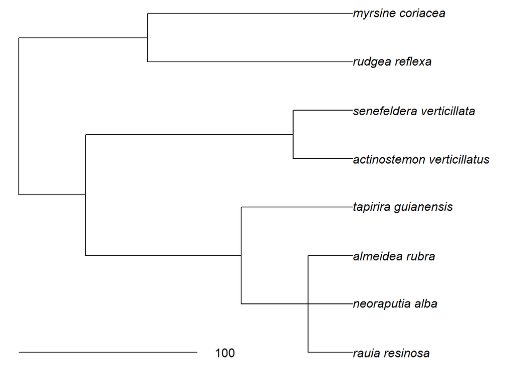

```r
plot(collapse.singles(dated.clean), no.margin=TRUE)
add.scale.bar(length = 100)
```

```r
# plot.phylo(collapse.singles(dated.clean), type = "phylogram", use.edge.length = TRUE, show.tip.label = TRUE, show.node.label = TRUE, edge.color = "grey10")
# nodelabels()
# tiplabels()
#
# cophenetic.phylo(collapse.singles(dated.clean))
```

## Organizando dados para análise funcional

Pensar em um worflow para a manipulação dos dados brutos direto no excel, levando em conta a variação intra-específica.

Preparar output (matriz) para as análises.

```r
# O comando abaixo criará uma planilha do Excel com os nomes
# das espécies agregados.
# MUITO CUIDADO COM O USO DESSA FUNÇÃO!
# ELA SOBRESCREVE QUALQUER ARQUIVO!
# DEVE SER UTILIZADA, IDEALMENTE, QUANDO TODOS
# OS NOMES DAS ESPÉCIE ESTIVEREM DISPONÍVEIS.

# write.xlsx(names.aggregated,
#            "data/[somente-visualizacao]trait-data.xlsx",
#            sheetName = "spp-list")
```